# Bounding box detection - Racoon data

## Data files

- images_racoon.rar: contain images of racoons
- train_labels.cv: contains coordinates for bounding box for every image

```python
from google.colab import drive
drive.mount('/content/drive')
```

```python
import os
path ='/content/drive/MyDrive/LablFiles/AdvancedVision/Internal_Lab/img/'
os.chdir(path)
```

### Import the necessary libraries

```python
import numpy as np
import pandas as pd
```

### Mount to drive

```python
#ALready done in above section
```

### Change directory

```python
import os
path ='/content/drive/MyDrive/LablFiles/AdvancedVision/Internal_Lab/'
os.chdir(path)
```

### Load the training data from train.csv file

```python
dfimg = pd.read_csv('train_labels.csv')
```

### Print the shape of the train dataset

```python
dfimg.shape
```

```
(173, 8)
```

```python
dfimg.head()
```

|  | filename | width | height | class | xmin | ymin | xmax | ymax |
| --- | --- | --- | --- | --- | --- | --- | --- | --- |
| 0 | raccoon-17.jpg | 259 | 194 | raccoon | 95 | 60 | 167 | 118 |
| 1 | raccoon-11.jpg | 660 | 432 | raccoon | 3 | 1 | 461 | 431 |
| 2 | raccoon-63.jpg | 600 | 400 | raccoon | 74 | 107 | 280 | 290 |
| 3 | raccoon-63.jpg | 600 | 400 | raccoon | 227 | 93 | 403 | 298 |
| 4 | raccoon-60.jpg | 273 | 185 | raccoon | 58 | 33 | 197 | 127 |

### Declare a variable IMAGE_SIZE = 128 as we will be using MobileNet which will be taking Input shape as 128 * 128

```python
IMAGE_SIZE=128
```

### With the help of csv.reader write a for loop which can load the train.csv file and store the path, width and height, x0, y0, x1, y1 in individual variables.

1. Create a list variable known as 'paths' which has all the path for all the training images
2. Create an array 'coords' which has the resized coordinates of the bounding box for the training images

Note: All the training images should be resized to 128 *128 as it is the input shape of MobileNet (which we will be using for Object detection). Hence the corresponding coordinates of the bounding boxes should be changed to match the image dimension of 128* 128

```python
imagesPath ='/content/drive/MyDrive/LablFiles/AdvancedVision/Internal_Lab/img/'
```

```python
def SetImagePath(filename) :
  return imagesPath + filename
```

### Write a for loop which can load all the training images into a variable 'batch_images' using the paths from the 'paths' variable

Note: Convert the image to RGB scale as the MobileNet accepts 3 channels as inputs

```python
dfimg['CompletePath'] = dfimg['filename'].apply(SetImagePath)
```

```python
dfimg.head()
```

|  | filename | width | height | class | xmin | ymin | xmax | ymax | CompletePath |
| --- | --- | --- | --- | --- | --- | --- | --- | --- | --- |
| 0 | raccoon-17.jpg | 259 | 194 | raccoon | 95 | 60 | 167 | 118 | /content/drive/MyDrive/LablFiles/AdvancedVisio... |
| 1 | raccoon-11.jpg | 660 | 432 | raccoon | 3 | 1 | 461 | 431 | /content/drive/MyDrive/LablFiles/AdvancedVisio... |
| 2 | raccoon-63.jpg | 600 | 400 | raccoon | 74 | 107 | 280 | 290 | /content/drive/MyDrive/LablFiles/AdvancedVisio... |
| 3 | raccoon-63.jpg | 600 | 400 | raccoon | 227 | 93 | 403 | 298 | /content/drive/MyDrive/LablFiles/AdvancedVisio... |
| 4 | raccoon-60.jpg | 273 | 185 | raccoon | 58 | 33 | 197 | 127 | /content/drive/MyDrive/LablFiles/AdvancedVisio... |

```python
coords = np.zeros((len(dfimg),4))
```

```python
imagelst = []
```

```python
for index, row in dfimg.iterrows() :
  filename = row['filename']
  imagelst.append(imagesPath + filename)

  coords[index][0] = (row['xmin']/row['width']) * IMAGE_SIZE
  coords[index][1] = (row['ymin']/row['height']) * IMAGE_SIZE
  coords[index][2] = (row['xmax']/row['width']) * IMAGE_SIZE
  coords[index][3] = (row['ymax']/row['height']) * IMAGE_SIZE
```

```python
coords[0]
```

```
array([46.94980695, 39.58762887, 82.53281853, 77.8556701 ])
```

```python
from PIL import Image
```

```python
from tensorflow.keras.applications.mobilenet import preprocess_input
```

```python
batch_images = np.zeros((len(imagelst), IMAGE_SIZE, IMAGE_SIZE,3))
```

```python
for i, image in enumerate(imagelst) :
  #Read image
  img = Image.open(image)
  #resize
  img = img.resize((IMAGE_SIZE,IMAGE_SIZE))
  #convert into RGB
  img = img.convert('RGB')
  batch_images[i] = preprocess_input(np.array(img))
```

```python
batch_images[0].shape
```

```
(128, 128, 3)
```

```python
import matplotlib.pyplot as plt
```

```
Clipping input data to the valid range for imshow with RGB data ([0..1] for floats or [0..255] for integers).
```

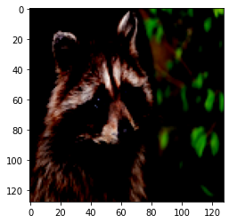

```python
 plt.imshow(batch_images[1])
```

### Import MobileNet and load MobileNet into a variable named 'model' which takes input shape of 128 *128* 3.

### Freeze all the layers and Add convolution layers and reshape layers at the end to ensure the output has 4 coordinates.

```python
import tensorflow as tf
tf.keras.backend.clear_session()
```

```python
model = tf.keras.applications.MobileNet(include_top=False,input_shape=(IMAGE_SIZE,IMAGE_SIZE,3))
```

```
Downloading data from https://storage.googleapis.com/tensorflow/keras-applications/mobilenet/mobilenet_1_0_128_tf_no_top.h5
```

```python
from tensorflow.keras.layers import Conv2D, Reshape
from tensorflow.keras import  Model
```

```python
#Lets freeze layers
for layer in model.layers :
  layer.trainable = False

#Add convolution layers and reshape layers at the end to ensure the output has 4
x = model.layers[-1].output
x = Conv2D(4,kernel_size=4) (x)
x = Reshape((4,))(x)
```

```python
model = Model(inputs=model.input,outputs=x)
```

## Plot the model and view the whole skeleton using plot_model.

```python
tf.keras.utils.plot_model(model)
```

[figure not shown]

### Define a custom loss function IoU which calculates Intersection Over Union

```python
from tensorflow.keras.backend import epsilon
```

```python
def loss(gt,pred):
    intersections = 0
    unions = 0
    diff_width = np.minimum(gt[:,0] + gt[:,2], pred[:,0] + pred[:,2]) - np.maximum(gt[:,0], pred[:,0])
    diff_height = np.minimum(gt[:,1] + gt[:,3], pred[:,1] + pred[:,3]) - np.maximum(gt[:,1], pred[:,1])
    intersection = diff_width * diff_height

    # Compute union
    area_gt = gt[:,2] * gt[:,3]
    area_pred = pred[:,2] * pred[:,3]
    union = area_gt + area_pred - intersection

#     Compute intersection and union over multiple boxes
    for j, _ in enumerate(union):
        if union[j] > 0 and intersection[j] > 0 and union[j] >= intersection[j]:
            intersections += intersection[j]
            unions += union[j]

    # Compute IOU. Use epsilon to prevent division by zero
    iou = np.round(intersections / (unions + epsilon()), 4)
    iou = iou.astype(np.float32)
    return iou

def IoU(y_true, y_pred):
    iou = tf.py_function(loss, [y_true, y_pred], tf.float32)
    return iou
```

### Write model.compile function & model.fit function with:

1. Optimizer = Adam, Loss = 'mse' and metrics = IoU
2. Epochs = 30, batch_size = 32, verbose = 1

```python
model.compile(optimizer='adam',loss='mse',metrics=[IoU])
model.fit(batch_images,coords,epochs=30,batch_size=32,verbose=1)
```

```
<tensorflow.python.keras.callbacks.History at 0x7f2b235306d0>
```

### Pick a test image from the given data

```python
def processImage (image) :
   #Read image
  img = Image.open(image)
  #resize
  img = img.resize((IMAGE_SIZE,IMAGE_SIZE))
  #convert into RGB
  img = img.convert('RGB')
  return preprocess_input(np.array(img))
```

Consider any image from the training set

```python
anyImage  = imagelst[75]
testimage = processImage(anyImage)
```

```
Clipping input data to the valid range for imshow with RGB data ([0..1] for floats or [0..255] for integers).
```

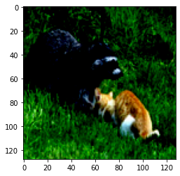

```python
 plt.imshow(testimage)
```

### Resize the image to 128 * 128 and preprocess the image for the MobileNet model

```python
#Already done in above section
```

### Predict the coordinates of the bounding box for the given test image

```python
region = model.predict(np.expand_dims(testimage,axis=0))[0]
```

### Plot the test image using .imshow and draw a boundary box around the image with the coordinates obtained from the model

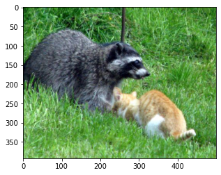

```python
unscaled = Image.open(anyImage)
plt.imshow(unscaled)
```

```python
image_width, image_height = unscaled.size[0], unscaled.size[1]
```

```python
import  matplotlib.patches as  patches
```

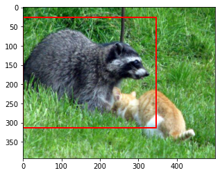

```python
x0 = int(region[0] * image_width / IMAGE_SIZE) # Scale the BBox
y0 = int(region[1] * image_height / IMAGE_SIZE)

x1 = int((region[2]) * image_width / IMAGE_SIZE)
y1 = int((region[3]) * image_height / IMAGE_SIZE)


# Create figure and axes
fig,ax = plt.subplots(1)

# Display the image
ax.imshow(unscaled)

# Create a Rectangle patch
rect = patches.Rectangle((x0, y0), (x1 - x0) , (y1 - y0) , linewidth=2, edgecolor='r', facecolor='none')

# Add the patch to the Axes
ax.add_patch(rect)

plt.show()
```

Lets consider image which was not part of training set

```python
data = os.listdir(imagesPath)
testdata = []

for file in data :
  if file not in dfimg['filename'].values :
    testdata.append(file)
```

```
Clipping input data to the valid range for imshow with RGB data ([0..1] for floats or [0..255] for integers).
```

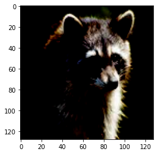

```python
anyImage  = imagesPath + testdata[4]
testimage = processImage(anyImage)
plt.imshow(testimage)
```

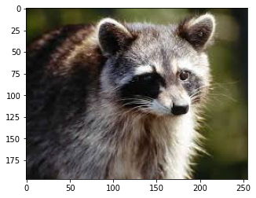

```python
unscaled = Image.open(anyImage)
plt.imshow(unscaled)
```

```python
# DO Prediction
region = model.predict(np.expand_dims(testimage,axis=0))[0]
```

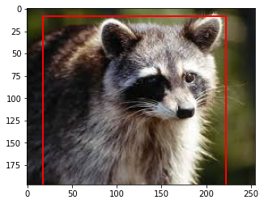

```python
image_width, image_height = unscaled.size[0], unscaled.size[1]

x0 = int(region[0] * image_width / IMAGE_SIZE) # Scale the BBox
y0 = int(region[1] * image_height / IMAGE_SIZE)

x1 = int((region[2]) * image_width / IMAGE_SIZE)
y1 = int((region[3]) * image_height / IMAGE_SIZE)
# Create figure and axes
fig,ax = plt.subplots(1)
# Display the image
ax.imshow(unscaled)
# Create a Rectangle patch
rect = patches.Rectangle((x0, y0), (x1 - x0) , (y1 - y0) , linewidth=2, edgecolor='r', facecolor='none')
# Add the patch to the Axes
ax.add_patch(rect)
plt.show()
```

# VGG16 Implementation

# VGG 16 Implementation

### Define a variable Image_size which takes accurate input according to the VGG16 model.

```python
import tensorflow as tf
tf.keras.backend.clear_session()
```

```python
IMAGE_SIZE=224
```

### With the help of csvr.reader write a for loop which can load the train.csv file and store the path, width, height, x0,y0,x1,y1 in induvidual variables.

1. Create a list variable known as 'path' which has all the path for all the training images
2. Create an array 'coords' which has the resized coordinates of the bounding box for the training images

```python
coords = np.zeros((len(dfimg),4))

imagelst = []

for index, row in dfimg.iterrows() :
  filename = row['filename']
  imagelst.append(imagesPath + filename)

  coords[index][0] = (row['xmin']/row['width']) * IMAGE_SIZE
  coords[index][1] = (row['ymin']/row['height']) * IMAGE_SIZE
  coords[index][2] = (row['xmax']/row['width']) * IMAGE_SIZE
  coords[index][3] = (row['ymax']/row['height']) * IMAGE_SIZE
```

### Write a for loop which can load all the training images into a variable 'batch_images' using the paths from the 'paths' variable

Note: Convert the image to RGB scale as the VGG16 accepts 3 channels as inputs

```python
batch_images = np.zeros((len(imagelst), IMAGE_SIZE, IMAGE_SIZE,3))

for i, image in enumerate(imagelst) :
  #Read image
  img = Image.open(image)
  #resize
  img = img.resize((IMAGE_SIZE,IMAGE_SIZE))
  #convert into RGB
  img = img.convert('RGB')
  batch_images[i] = preprocess_input(np.array(img))
```

```python
batch_images[0].shape
```

```
(224, 224, 3)
```

### Define a vgg16 model and plot the model using plot_model function.

Hint:- Use RepeatVector,Conv1D,GlobalAveragePooling2D(optional to learner)

```python
from tensorflow.keras.applications.vgg16 import VGG16
```

```python
model = tf.keras.applications.VGG16(include_top=False,input_shape=(IMAGE_SIZE,IMAGE_SIZE,3))

#Lets freeze layers
for layer in model.layers :
  layer.trainable = False

#Add convolution layers and reshape layers at the end to ensure the output has 4
x = model.layers[-1].output
x = Conv2D(4,kernel_size=7) (x)
x = Reshape((4,))(x)
```

```
Downloading data from https://storage.googleapis.com/tensorflow/keras-applications/vgg16/vgg16_weights_tf_dim_ordering_tf_kernels_notop.h5
```

```python
model = Model(inputs=model.input,outputs=x)
```

### Plot the Vgg16 model using plot_model function.

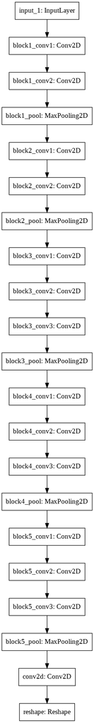

```python
tf.keras.utils.plot_model(model)
```

### Write model.compile function & model.fit function with:

1. Optimizer = Adam, Loss = 'mse' and metrics = IoU
2. Epochs = 30, batch_size = 32, verbose = 1

```python
from datetime import datetime
from packaging import version
import tensorflow as tf
from tensorflow import keras
```

```python
logdir="/content/drive/MyDrive/LablFiles/AdvancedVision/Internal_Lab/logs/fit/" + datetime.now().strftime("%Y%m%d-%H%M%S")
tensorboard_callback = keras.callbacks.TensorBoard(log_dir=logdir)
```

```python
model.compile(optimizer='adam',loss='mse',metrics=[IoU])
model.fit(batch_images,coords,epochs=30,batch_size=32,verbose=1,callbacks=[tensorboard_callback])
```

```
<tensorflow.python.keras.callbacks.History at 0x7f2aba420a50>
```

### Pick a test image from the given data

Lets consider image from training set data

```python
def processImage (image) :
   #Read image
  img = Image.open(image)
  #resize
  img = img.resize((IMAGE_SIZE,IMAGE_SIZE))
  #convert into RGB
  img = img.convert('RGB')
  return preprocess_input(np.array(img))
```

```
Clipping input data to the valid range for imshow with RGB data ([0..1] for floats or [0..255] for integers).
```

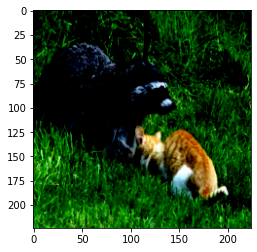

```python
anyImage  = imagelst[75]
testimage = processImage(anyImage)
plt.imshow(testimage)
```

### Predict the coordinates of the bounding box for the given test image

```python
region = model.predict(np.expand_dims(testimage,axis=0))[0]
```

### Plot the test image using .imshow and draw a boundary box around the image with the coordinates obtained from the model

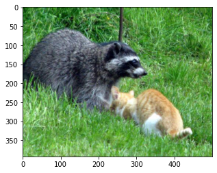

```python
unscaled = Image.open(anyImage)
plt.imshow(unscaled)
```

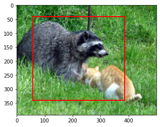

```python
image_width, image_height = unscaled.size[0], unscaled.size[1]

x0 = int(region[0] * image_width / IMAGE_SIZE) # Scale the BBox
y0 = int(region[1] * image_height / IMAGE_SIZE)

x1 = int((region[2]) * image_width / IMAGE_SIZE)
y1 = int((region[3]) * image_height / IMAGE_SIZE)


# Create figure and axes
fig,ax = plt.subplots(1)

# Display the image
ax.imshow(unscaled)

# Create a Rectangle patch
rect = patches.Rectangle((x0, y0), (x1 - x0) , (y1 - y0) , linewidth=2, edgecolor='r', facecolor='none')

# Add the patch to the Axes
ax.add_patch(rect)

plt.show()
```

Lets consider image which was not part of training data

```python
data = os.listdir(imagesPath)
testdata = []

for file in data :
  if file not in dfimg['filename'].values :
    testdata.append(file)
```

```
Clipping input data to the valid range for imshow with RGB data ([0..1] for floats or [0..255] for integers).
```

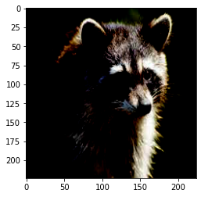

```python
anyImage  = imagesPath + testdata[4]
testimage = processImage(anyImage)
plt.imshow(testimage)
```

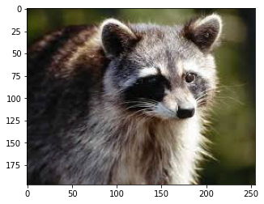

```python
unscaled = Image.open(anyImage)
plt.imshow(unscaled)
```

```python
# DO Prediction
region = model.predict(np.expand_dims(testimage,axis=0))[0]
```

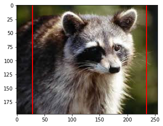

```python
image_width, image_height = unscaled.size[0], unscaled.size[1]

x0 = int(region[0] * image_width / IMAGE_SIZE) # Scale the BBox
y0 = int(region[1] * image_height / IMAGE_SIZE)

x1 = int((region[2]) * image_width / IMAGE_SIZE)
y1 = int((region[3]) * image_height / IMAGE_SIZE)
# Create figure and axes
fig,ax = plt.subplots(1)
# Display the image
ax.imshow(unscaled)
# Create a Rectangle patch
rect = patches.Rectangle((x0, y0), (x1 - x0) , (y1 - y0) , linewidth=2, edgecolor='r', facecolor='none')
# Add the patch to the Axes
ax.add_patch(rect)
plt.show()
```

### Visualizing model details in tensorboard

```python
!tensorboard dev upload \
  --logdir logs \
  --name "Sample op-level graph" \
  --one_shot
```

[output not shown]